# PA1. Reproducible Research ( Coursera)

## June 9th, 2014

# Loading and processing the data

This assignment makes use of data from a personal activity monitoring device. This device collects data at 5 minute intervals through out the day. The data consists of two months of data from an anonymous individual collected during the months of October and November, 2012 and include the number of steps taken in 5 minute intervals each day.

Exploration of the data and data structure.

```r
# download data from the source url
filepath <- "https://d396qusza40orc.cloudfront.net/repdata%2Fdata%2Factivity.zip"
download.file(filepath, destfile = paste(getwd(), "/", "activity.zip", sep = ""),
    method = "wget")
unzip("activity.zip")


df <- read.table("activity.csv", sep = ",", header = T)
sdf <- summary(df)
xt <- xtable(sdf)

print(xt, type = "html")
```

|  | steps | date | interval |
| --- | --- | --- | --- |
| 1 | Min. : 0 | 2012-10-01: 288 | Min. : 0 |
| 2 | 1st Qu.: 0 | 2012-10-02: 288 | 1st Qu.: 589 |
| 3 | Median : 0 | 2012-10-03: 288 | Median :1178 |
| 4 | Mean : 37 | 2012-10-04: 288 | Mean :1178 |
| 5 | 3rd Qu.: 12 | 2012-10-05: 288 | 3rd Qu.:1766 |
| 6 | Max. :806 | 2012-10-06: 288 | Max. :2355 |
| 7 | NA’s :2304 | (Other) :15840 |  |

The variables included in this dataset are:

- steps: Number of steps taking in a 5minute interval (missing values are coded as NA )
- date: The date on which the measurement was taken in YYYYMMDD format
- interval: Identifier for the 5minute interval in which measurement was taken

The dataset is stored in a commaseparatedvalue (CSV) file and there are a total of 17,568 observations in this dataset.

He have arround 288 observations per day.

# What is mean total number of steps taken per day?

```r
# no account of misssign values
df1 <- na.omit(df)
su <- tapply(df1$steps, df1$date, sum)
su <- as.numeric(su)
```

Histogram of total number of steps per day

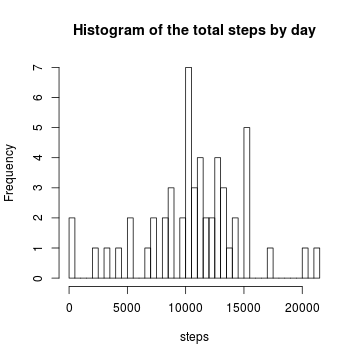

```r
hist(su, main = "Histogram of the total steps by day", breaks = 50, freq = T,
    xlab = "steps")
```

The mean of the total step per day is **10766.189** and the median is **10765**.

# What is the average daily activity pattern?

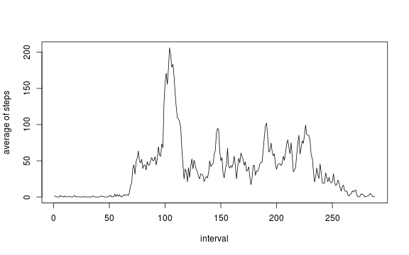

```r
me <- tapply(df1$steps, df1$interval, mean)
plot(me, type = "l", xlab = "interval", ylab = "average of steps")
```

```r
maxinterval1 <- dimnames(me)[[1]][rev(order(me))[1]]
maxi1 <- max(me)
```

The 5 minute interavl that on average across all the days in the dataset contains the maximum number of steps is the **835**, the maximun is 206.17.

# Imputing missing values

```r
nna <- as.numeric(sum(is.na(df$steps)))
```

The number of NA are: 2304

We will fill all of the missing values in the dataset with the mean for that 5? minute interval. And create a new dataset with the missing data filled in.

```r
df2 <- df  # with NAs
for (i in 1:nrow(df)) {
    # rellenamos con la media del intervalo, y creamos el dataf df2
    if (is.na(df$steps[i])) {
        MM <- mean(df$steps[which(df$interval == df$interval[i])], na.rm = T)
        if (!is.na(MM)) {
            df2$steps[i] <- MM
        } else {
            df2$steps[i] <- 99
        }
    }
}
# df2 is the new dataset with missing filled in
```

```r
su2 <- tapply(df2$steps, df2$date, sum)
su2 <- as.numeric(su2)
```

Histogram of total number of steps per day of the dataset without missig data

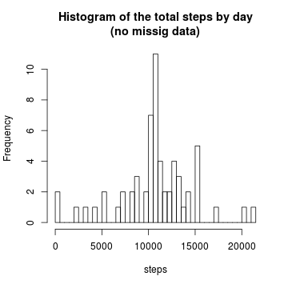

```r
hist(su2, main = "Histogram of the total steps by day\n(no missig data)", breaks = 50,
    freq = T, xlab = "steps")
```

After filling in the missing data with the mean of the interval, the mean of the total step per day is **10766.189** and the median is **10766.189**. So we found very small diferences, oly the median change a bit.

# Are there differences in activity patterns between weekdays and weekends?

```r
# change factor to dates and set if they are weekdays or weekends
dd <- as.character(df2$date)
dd <- as.Date(dd, "%Y-%m-%d")
dow <- weekdays(dd, abbreviate = T)  # 'sáb', 'dom'--> Saturday and Sunday
# table(dow)
dow[dow == "sáb" | dow == "dom"] <- "weekend"
dow[dow != "weekend"] <- "weekday"
table(dow)
```

dow weekday weekend 12960 4608

```r
df2 <- data.frame(df2, dow = factor(dow))
```

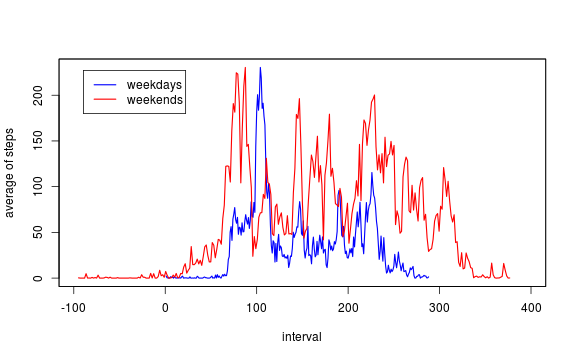

```r
# xyplot(steps~interval | dow, df2, col="blue",type="l")
par(mfrow=c(1,1))
dfaux<-df2[df2$dow=="weekday",]
me<-tapply(dfaux$steps, dfaux$interval, mean)
plot(me,type="l"
     , xlab="interval"
     , ylab="average of steps"
     ,col="blue"
     , xlim=c(0, 300)
     ,lwd=1.5
     , asp=T)
dfaux<-df2[df2$dow=="weekend",]
me<-tapply(dfaux$steps, dfaux$interval, mean)
par(new=TRUE)
plot(me,
     type="l",
     col="red",
     ylab="", xlab=""
     ,xaxt='n', yaxt='n'
     , xlim=c(0, 300)
     ,lwd=1.5)
legend("topleft", inset=.05
#        , title="jjjjj"
       ,c("weekdays","weekends")
       ,lty=c(1,1)
       ,lwd=c(1.5,1.5)
       ,col=c("blue","red")
       , horiz=F)
```

We observe that activity on the weekends tends to be more spread out over the day compared to the weekdays.

It seems that **on weekend the activity (steps) are more more spread out over the intervals (day time) that on weekdays**. It may be because day routines are diferent (work, vacation).

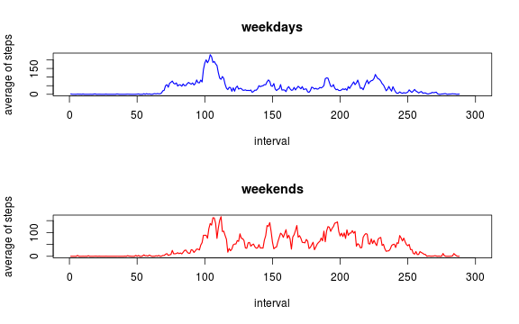

```r
par(mfrow=c(2,1))
dfaux<-df2[df2$dow=="weekday",]
me<-tapply(dfaux$steps, dfaux$interval, mean)
plot(me,type="l"
     , main="weekdays"
     , xlab="interval"
     , ylab="average of steps"
     ,col="blue"
     ,lwd=1.5
     , xlim=c(0, 300)
#      , asp=T
     )
dfaux<-df2[df2$dow=="weekend",]
me<-tapply(dfaux$steps, dfaux$interval, mean)
# par(new=TRUE)
plot(me,
     type="l"
     , main="weekends"
     , xlab="interval"
     , ylab="average of steps"
     , col="red"
#      , ylab="", xlab=""
     , xlim=c(0, 300)
#      ,xaxt='n', yaxt='n'
     , lwd=1.5)
```